# Estudios de Informática, Multimedia y Telecomunicaciones

Autor: Gerard Alcalde Gascón

Comenzaremos importando las distintas librerías que se emplearán a lo largo del proyecto.

```python
# Data wrangling
import pandas as pd
import numpy as np

# Visualization tools
import matplotlib.pyplot as plt
import matplotlib.patches as mpatches
import seaborn as sns

# Decision tree tools
from sklearn.model_selection import train_test_split
from sklearn.preprocessing import OneHotEncoder
from sklearn import tree
from sklearn.tree import export_text

# Evaluation of the decision tree
from sklearn import metrics
from sklearn.metrics import confusion_matrix, ConfusionMatrixDisplay, roc_curve, roc_auc_score

# Random forest
from sklearn.ensemble import RandomForestClassifier
from sklearn.datasets import make_classification

#Defining the different plot parameters to get a uniform look.
sns.set_theme()
sns.set_palette(palette="pastel")

# Font size parameters for the plotting
SMALL_SIZE = 8
MEDIUM_SIZE = 10
BIGGER_SIZE = 12

plt.rc('font', size=SMALL_SIZE)          # controls default text sizes
plt.rc('axes', titlesize=BIGGER_SIZE)     # fontsize of the axes title
plt.rc('axes', labelsize=MEDIUM_SIZE)    # fontsize of the x and y labels
plt.rc('xtick', labelsize=SMALL_SIZE)    # fontsize of the tick labels
plt.rc('ytick', labelsize=SMALL_SIZE)    # fontsize of the tick labels
plt.rc('legend', fontsize=SMALL_SIZE)    # legend fontsize
plt.rc('figure', titlesize=BIGGER_SIZE)  # fontsize of the figure title
```

# 1. Análisis descriptivo y de correlaciones

## 1.1. Preprocesado de los datos

Primero de todo procedemos a importar el dataset y almacernarlo en un dataframe

```python
df = pd.read_csv("credit.csv")
df.head()
```

|  | checking_balance | months_loan_duration | credit_history | purpose | amount | savings_balance | employment_length | installment_rate | personal_status | other_debtors | ... | property | age | installment_plan | housing | existing_credits | default | dependents | telephone | foreign_worker | job |
| --- | --- | --- | --- | --- | --- | --- | --- | --- | --- | --- | --- | --- | --- | --- | --- | --- | --- | --- | --- | --- | --- |
| 0 | < 0 DM | 6 | critical | radio/tv | 1169 | unknown | > 7 yrs | 4 | single male | none | ... | real estate | 67 | none | own | 2 | 1 | 1 | yes | yes | skilled employee |
| 1 | 1 - 200 DM | 48 | repaid | radio/tv | 5951 | < 100 DM | 1 - 4 yrs | 2 | female | none | ... | real estate | 22 | none | own | 1 | 2 | 1 | none | yes | skilled employee |
| 2 | unknown | 12 | critical | education | 2096 | < 100 DM | 4 - 7 yrs | 2 | single male | none | ... | real estate | 49 | none | own | 1 | 1 | 2 | none | yes | unskilled resident |
| 3 | < 0 DM | 42 | repaid | furniture | 7882 | < 100 DM | 4 - 7 yrs | 2 | single male | guarantor | ... | building society savings | 45 | none | for free | 1 | 1 | 2 | none | yes | skilled employee |
| 4 | < 0 DM | 24 | delayed | car (new) | 4870 | < 100 DM | 1 - 4 yrs | 3 | single male | none | ... | unknown/none | 53 | none | for free | 2 | 2 | 2 | none | yes | skilled employee |

5 rows × 21 columns

```python
df.shape
```

```
(1000, 21)
```

El dataset de estudio contiene 21 columnas diferentes y un total de 1000 registros, a continuación se muestra el listado de atributos y su tipo.

```python
df.dtypes
```

```
checking_balance        object
months_loan_duration     int64
credit_history          object
purpose                 object
amount                   int64
savings_balance         object
employment_length       object
installment_rate         int64
personal_status         object
other_debtors           object
residence_history        int64
property                object
age                      int64
installment_plan        object
housing                 object
existing_credits         int64
default                  int64
dependents               int64
telephone               object
foreign_worker          object
job                     object
dtype: object
```

Vamos a mostrar los valores únicos de los atributos categoricos.

```python
for column in ["checking_balance", "credit_history", "purpose", "savings_balance", "employment_length",
"personal_status", "other_debtors", "property", "installment_plan", "housing", "telephone", "foreign_worker", "job"]:
    print("{}: {}".format(column,df[column].unique()))
```

```
checking_balance: ['< 0 DM' '1 - 200 DM' 'unknown' '> 200 DM']
credit_history: ['critical' 'repaid' 'delayed' 'fully repaid' 'fully repaid this bank']
purpose: ['radio/tv' 'education' 'furniture' 'car (new)' 'car (used)' 'business'
 'domestic appliances' 'repairs' 'others' 'retraining']
savings_balance: ['unknown' '< 100 DM' '501 - 1000 DM' '> 1000 DM' '101 - 500 DM']
employment_length: ['> 7 yrs' '1 - 4 yrs' '4 - 7 yrs' 'unemployed' '0 - 1 yrs']
personal_status: ['single male' 'female' 'divorced male' 'married male']
other_debtors: ['none' 'guarantor' 'co-applicant']
property: ['real estate' 'building society savings' 'unknown/none' 'other']
installment_plan: ['none' 'bank' 'stores']
housing: ['own' 'for free' 'rent']
telephone: ['yes' 'none']
foreign_worker: ['yes' 'no']
job: ['skilled employee' 'unskilled resident' 'mangement self-employed'
 'unemployed non-resident']
```

Vemos que 13 de las variables son de tipo categorico o Strings y 8 de ellas son de tipo entero. Las distintas variables de las que disponemos son:

- checking_balance: Estado actual de la cuenta. Puede ser "< 0 DM", "0<= ... < 200 DM" o ">= 200 DM" donde DM hace referencia a Deutsch Mark, moneda anterior al € en Alemania
- months_loan_duration: Duración del prestamo en meses
- credit_history: Historial de credito. Puede ser: 'critical', 'repaid', 'delayed', 'fully repaid' o 'fully repaid this bank'
- purpose: 10 categorías distintas definiendo el proposito del prestamo.
- amount: Cantidad del prestamo
- savings_balance: Ahorros del solicitante del prestamo. Categorizado con: '< 100 DM', '101 - 500 DM', '501 - 1000 DM' o '> 1000 DM'
- employment_length: Antigüedad laboral. Categorizado con: '0 - 1 yrs', '1 - 4 yrs', '4 - 7 yrs', '> 7 yrs' o 'unemployed'
- installment_rate: Representa el porcentaje de los ingresos que se destina a otros prestamos. Esta categorizado en 4 categorias 1-4, pero no se especifica a que hace referencia.
- personal_status: Sexo y estado personal. Se han encontrado las categorias 'single male', 'female', 'divorced male' y 'married male', aunque técnicamente también se debería haber discretizado el estado personal de las mujeres.
- other_debtors: Indica si hay otros deudores para el prestamos y si lo solicitan en conjunto o lo abalan. Estos son: 'none', 'guarantor' y 'co-applicant'
- residence_history: Antingüedad en la vivienda actual.
- property: Propiedad de mayor valor que posee el solicitante, en orden serán: 'real estate', 'building society savings', 'other' y 'unknown/none'
- age: Edad del solicitante
- installment_plan: Otros prestamos. Puede ser: 'none', 'bank' o 'stores'
- housing: Propiedad de su vivienda. Puede ser: 'own', 'for free' o 'rent'
- existing_credits: Número de prestamos existentes en este banco.
- default: Variable objetivo, evalua el riesgo de un cliente de no devolver el credito. Puede ser 1: Good risk, 2: Bad risk
- dependents: Número de personas dependientes
- telephone: Si su número de teléfono existe en los registros del cliente. Puede ser: 'yes' o 'none'
- foreign_worker: Indica si el solicitante es un trabajador extranjero. Puede ser 'yes' o 'no'
- job: indica el tipo de trabajo del solicitante. Puede ser: 'skilled employee', 'unskilled resident', 'mangement self-employed' o 'unemployed non-resident'

A continuación, se evalua si existen registros nulos en los distintos atributos.

```python
# Sum of the null values for each atribute
df.isnull().sum()
```

```
checking_balance        0
months_loan_duration    0
credit_history          0
purpose                 0
amount                  0
savings_balance         0
employment_length       0
installment_rate        0
personal_status         0
other_debtors           0
residence_history       0
property                0
age                     0
installment_plan        0
housing                 0
existing_credits        0
default                 0
dependents              0
telephone               0
foreign_worker          0
job                     0
dtype: int64
```

Se observa que no hay registros nulos para ningún atributo y además se ha observado que la mayoría de variables ya estan discretizadas, por lo tanto nos encontramos con un dataset ya preprocesado. No obstante, se decide discretizar otras variables numericas para poderlas estudiar mejor.

Empezamos discretizando months_loan_duration. Primero observamos su distribución:

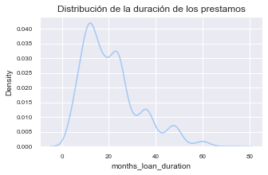

```python
# Assign figure size
plt.figure(figsize=(5,3))

# Create de density plot
sns.kdeplot(data=df, x="months_loan_duration")

# Assign title to the plot
plt.title("Distribución de la duración de los prestamos")

# Plot the density plot
plt.show()
```

Viendo esta distribución se opta por realizar la discretización en la duración del prestamos en "<18_months", "18-36_months", ">36_months".

```python
# Discretization of the months_loan_duration column
bins = [0, 18, 36, 100]
df["months_loan_duration_categorical"] = pd.cut(df.months_loan_duration, bins , labels = ["18_months", "18-36_months", "36_months"])
df.head()
```

|  | checking_balance | months_loan_duration | credit_history | purpose | amount | savings_balance | employment_length | installment_rate | personal_status | other_debtors | ... | age | installment_plan | housing | existing_credits | default | dependents | telephone | foreign_worker | job | months_loan_duration_categorical |
| --- | --- | --- | --- | --- | --- | --- | --- | --- | --- | --- | --- | --- | --- | --- | --- | --- | --- | --- | --- | --- | --- |
| 0 | < 0 DM | 6 | critical | radio/tv | 1169 | unknown | > 7 yrs | 4 | single male | none | ... | 67 | none | own | 2 | 1 | 1 | yes | yes | skilled employee | 18_months |
| 1 | 1 - 200 DM | 48 | repaid | radio/tv | 5951 | < 100 DM | 1 - 4 yrs | 2 | female | none | ... | 22 | none | own | 1 | 2 | 1 | none | yes | skilled employee | 36_months |
| 2 | unknown | 12 | critical | education | 2096 | < 100 DM | 4 - 7 yrs | 2 | single male | none | ... | 49 | none | own | 1 | 1 | 2 | none | yes | unskilled resident | 18_months |
| 3 | < 0 DM | 42 | repaid | furniture | 7882 | < 100 DM | 4 - 7 yrs | 2 | single male | guarantor | ... | 45 | none | for free | 1 | 1 | 2 | none | yes | skilled employee | 36_months |
| 4 | < 0 DM | 24 | delayed | car (new) | 4870 | < 100 DM | 1 - 4 yrs | 3 | single male | none | ... | 53 | none | for free | 2 | 2 | 2 | none | yes | skilled employee | 18-36_months |

5 rows × 22 columns

Para la variable age vamos a realizar un ejercicio similar, primero vemos la distribución de la edad de los clientes.

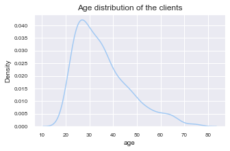

```python
# Assign figure size
plt.figure(figsize=(5,3))

# Create de density plot
sns.kdeplot(data=df, x="age")

# Assign title to the plot
plt.title("Age distribution of the clients")

# Plot the density plot
plt.show()
```

Se observa que la mayoría de los clientes son de entre 20-40 años con un pico en los 26-28 años aproximadamente. Se opta por realizar una discretización de edad que sea:

- Young: <30 años
- Young-Middle: 30-45 años
- Middle: 45-60 años
- Old: >60 años

```python
# Discretization of the age column
bins = [0, 30, 45, 60, 100]
df["age_categorical"] = pd.cut(df.age, bins , labels = ["Young (0-30)", "Young-Middle(30-45)", "Middle(45-60)", "Old(+60)"])
df.head()
```

|  | checking_balance | months_loan_duration | credit_history | purpose | amount | savings_balance | employment_length | installment_rate | personal_status | other_debtors | ... | installment_plan | housing | existing_credits | default | dependents | telephone | foreign_worker | job | months_loan_duration_categorical | age_categorical |
| --- | --- | --- | --- | --- | --- | --- | --- | --- | --- | --- | --- | --- | --- | --- | --- | --- | --- | --- | --- | --- | --- |
| 0 | < 0 DM | 6 | critical | radio/tv | 1169 | unknown | > 7 yrs | 4 | single male | none | ... | none | own | 2 | 1 | 1 | yes | yes | skilled employee | 18_months | Old(+60) |
| 1 | 1 - 200 DM | 48 | repaid | radio/tv | 5951 | < 100 DM | 1 - 4 yrs | 2 | female | none | ... | none | own | 1 | 2 | 1 | none | yes | skilled employee | 36_months | Young (0-30) |
| 2 | unknown | 12 | critical | education | 2096 | < 100 DM | 4 - 7 yrs | 2 | single male | none | ... | none | own | 1 | 1 | 2 | none | yes | unskilled resident | 18_months | Middle(45-60) |
| 3 | < 0 DM | 42 | repaid | furniture | 7882 | < 100 DM | 4 - 7 yrs | 2 | single male | guarantor | ... | none | for free | 1 | 1 | 2 | none | yes | skilled employee | 36_months | Young-Middle(30-45) |
| 4 | < 0 DM | 24 | delayed | car (new) | 4870 | < 100 DM | 1 - 4 yrs | 3 | single male | none | ... | none | for free | 2 | 2 | 2 | none | yes | skilled employee | 18-36_months | Middle(45-60) |

5 rows × 23 columns

amount también es una variable continua, a continuación mostramos un gráfico de densidad para tratar de discretizarla y así poder analizarla mejor posteriormente

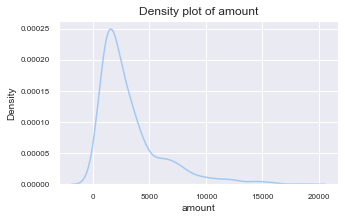

```python
# Assign figure size
plt.figure(figsize=(5,3))

# Create de density plot
sns.kdeplot(data=df, x="amount")

# Assign title to the plot
plt.title("Density plot of amount")

# Plot the density plot
plt.show()
```

Vemos como se agrupan la mayor parte de los registros entorno a los 2000DM, realizaremos una discretización en tres grupos:

- -3000
- 3000-5000
- +5000

```python
# Discretization of the amount column
bins = [0, 3000, 5000, 100000]
df["amount_categorical"] = pd.cut(df.amount, bins , labels = ["0-3000", "3000-5000", "+5000"])
df.head()
```

|  | checking_balance | months_loan_duration | credit_history | purpose | amount | savings_balance | employment_length | installment_rate | personal_status | other_debtors | ... | housing | existing_credits | default | dependents | telephone | foreign_worker | job | months_loan_duration_categorical | age_categorical | amount_categorical |
| --- | --- | --- | --- | --- | --- | --- | --- | --- | --- | --- | --- | --- | --- | --- | --- | --- | --- | --- | --- | --- | --- |
| 0 | < 0 DM | 6 | critical | radio/tv | 1169 | unknown | > 7 yrs | 4 | single male | none | ... | own | 2 | 1 | 1 | yes | yes | skilled employee | 18_months | Old(+60) | 0-3000 |
| 1 | 1 - 200 DM | 48 | repaid | radio/tv | 5951 | < 100 DM | 1 - 4 yrs | 2 | female | none | ... | own | 1 | 2 | 1 | none | yes | skilled employee | 36_months | Young (0-30) | +5000 |
| 2 | unknown | 12 | critical | education | 2096 | < 100 DM | 4 - 7 yrs | 2 | single male | none | ... | own | 1 | 1 | 2 | none | yes | unskilled resident | 18_months | Middle(45-60) | 0-3000 |
| 3 | < 0 DM | 42 | repaid | furniture | 7882 | < 100 DM | 4 - 7 yrs | 2 | single male | guarantor | ... | for free | 1 | 1 | 2 | none | yes | skilled employee | 36_months | Young-Middle(30-45) | +5000 |
| 4 | < 0 DM | 24 | delayed | car (new) | 4870 | < 100 DM | 1 - 4 yrs | 3 | single male | none | ... | for free | 2 | 2 | 2 | none | yes | skilled employee | 18-36_months | Middle(45-60) | 3000-5000 |

5 rows × 24 columns

residence_history, existing_credits and dependents también son numéricas, pero deberían ser valores bajos, a continuación vamos a mostrar sus valores únicos:

```python
for column in ["existing_credits", "dependents", "residence_history"]:
    print("{}: {}".format(column,df[column].unique()))
```

```
existing_credits: [2 1 3 4]
dependents: [1 2]
residence_history: [4 2 3 1]
```

Observamos que aunque sean variables integer, se pueden valorar todos los datos de los que disponen sin necesidad de discretizar las variables ya que tienen una cantidad de valores muy reducidos.

Para la variable personal_status se había observado que para hombres se especificaba el estado sentimental mientras que para las mujeres no, por ellos se decide generar una nueva columna que almacene los datos del sexo exclusivamente "sex" y posteriormente modificar esta columna dejando "unknown female" para las mujeres. A la hora de estudiar esta variable será necesario tener presente el sesgo que hay en la situación sentimental en la que tan solo se contemplan hombres.

```python
# Generation of the "sex" column
df["sex"] = ""

# Adding values to "sex"
df.loc[(df.personal_status == "single male") | (df.personal_status == "divorced male") | (df.personal_status == "married male"), "sex"] = "male"
df.loc[(df.personal_status == "female") | (df.personal_status == "divorced male") | (df.personal_status == "married male"), "sex"] = "female"

# Modifying the column personal_status
df.loc[df.personal_status == "female", "personal_status"] = "unknown female"

# Show the dataframe
df.head()
```

|  | checking_balance | months_loan_duration | credit_history | purpose | amount | savings_balance | employment_length | installment_rate | personal_status | other_debtors | ... | existing_credits | default | dependents | telephone | foreign_worker | job | months_loan_duration_categorical | age_categorical | amount_categorical | sex |
| --- | --- | --- | --- | --- | --- | --- | --- | --- | --- | --- | --- | --- | --- | --- | --- | --- | --- | --- | --- | --- | --- |
| 0 | < 0 DM | 6 | critical | radio/tv | 1169 | unknown | > 7 yrs | 4 | single male | none | ... | 2 | 1 | 1 | yes | yes | skilled employee | 18_months | Old(+60) | 0-3000 | male |
| 1 | 1 - 200 DM | 48 | repaid | radio/tv | 5951 | < 100 DM | 1 - 4 yrs | 2 | unknown female | none | ... | 1 | 2 | 1 | none | yes | skilled employee | 36_months | Young (0-30) | +5000 | female |
| 2 | unknown | 12 | critical | education | 2096 | < 100 DM | 4 - 7 yrs | 2 | single male | none | ... | 1 | 1 | 2 | none | yes | unskilled resident | 18_months | Middle(45-60) | 0-3000 | male |
| 3 | < 0 DM | 42 | repaid | furniture | 7882 | < 100 DM | 4 - 7 yrs | 2 | single male | guarantor | ... | 1 | 1 | 2 | none | yes | skilled employee | 36_months | Young-Middle(30-45) | +5000 | male |
| 4 | < 0 DM | 24 | delayed | car (new) | 4870 | < 100 DM | 1 - 4 yrs | 3 | single male | none | ... | 2 | 2 | 2 | none | yes | skilled employee | 18-36_months | Middle(45-60) | 3000-5000 | male |

5 rows × 25 columns

Con estas discretizaciones y viendo que no existen valores nulos procedemos a estudiar los distintos atributos. Empezaremos evaluando la distribución de la variable objetivo "default". Para ello mostraremos un histograma e indicaremos el porcentaje de cada opción.

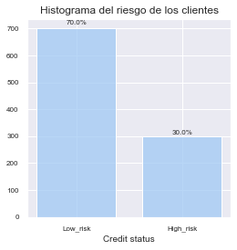

```python
# Transform the values to get a more comprensible value than 1 and 2
df.loc[df.default == 1, "default"] = "Low_risk"
df.loc[df.default == 2, "default"] = "High_risk"

# Plot the variable with a histplot
plt.figure(figsize=(4,4))
ax = sns.histplot(data=df, x="default", shrink=0.75)

# Set title and others
plt.title("Histograma del riesgo de los clientes")
plt.xlabel("Credit status")
plt.ylabel("")

# Anotate the percentage above the bars
total = len(df)
for p in ax.patches:
    width = p.get_width()
    height = p.get_height()
    percentage = height/total*100
    x, y = p.get_xy()
    ax.annotate("{:.1f}%".format(percentage), (x + width/2, y + height*1.02), ha='center')

plt.show()
```

Se observa que el 70% de los clientes que han solicitado un prestamo han sido categorizados como bajo riesgo, mientras que el 30% lo han hecho como alto riesgo. Estos datos serán importantes para poder comparar en el resto de categorías si esta proporción se mantiene o si para determinados grupos es superior o inferior y así poder obtener conclusiones.

## 1.2. Variables categóricas

### 1.2.1. Análisis de las variables categóricas

Inicialmente se va a hacer un estudio de las variables categóricas para evalúar su correlación con el nivel de riesgo asignado a un cliente.

A continuación se va a estudiar la relación entre los distintos atributos y nuestra variable objetivo default que nos indica el riesgo asignado al cliente. Comenzamos evaluando checking_balance. El objetivo es mostrar en un gráfico de barras apiladas para cada categoría de checking_balance el porcentaje de clientes asignados a alto y bajo riesgo. Como este código se va a utilizar para los distintos atributos se opta por englobarlo dentro de una función y así aplicarlo después de una manera más sencilla.

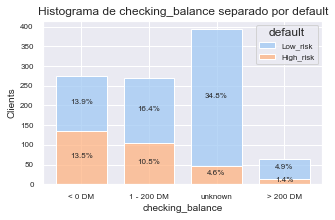

```python
def plot_stacked_histplot(df, var1, var2):
    # Set the figure size
    plt.figure(figsize=(5,3))

    # Histplot stacked by the default variable
    ax = sns.histplot(data=df, x=var1, hue=var2, multiple="stack", shrink = 0.75, discrete=True)

    # Set title and others
    plt.title("Histograma de {} separado por {}".format(var1, var2))
    plt.xlabel("{}".format(var1))
    plt.ylabel("Clients")

    # Plot the percentage of each bar segment
    total = len(df)
    for p in ax.patches:
        width = p.get_width()
        height = p.get_height()
        percentage = height/total*100
        x, y = p.get_xy()
        ax.annotate("{:.1f}%".format(percentage), (x + width/2, y + height/2), ha='center')

    # Show the plot
    plt.show()

plot_stacked_histplot(df, "checking_balance", "default")
```

A continuación se muestra una tabla donde se discretizan los valores que hemos visto en el gráfico anterior y se muestran los distintos porcentajes. La tabla la generaremos empleando un dataframe con pandas. Al igual que con el gráfico este trabajo lo repetiremos con cada variable y por ello lo vamos a englobar en una función.

```python
def show_summary_table(df, var1, var2):
    # Group and filter the data by the study attribute and the goal attribute
    df_table = df[[var1, var2]].groupby([var1, var2]).size().reset_index()
    df_table.columns = [var1, var2, "count"]

    # Add column percentage that will be filled later
    df_table["percentage"] = ""

    # Pivot the table to have the categories of the atribute as rows and count and percentage as columns
    pivoted = pd.pivot(data = df_table, columns=var2, index = var1, values = ["count", "percentage"])

    # Add the percentage of high and low risk clients per category of the attribute
    pivoted[("percentage","High_risk")] = (pivoted[('count', 'High_risk')])/(pivoted[('count', 'High_risk')] + pivoted[('count', 'Low_risk')])
    pivoted[("percentage","Low_risk")] = (pivoted[('count', 'Low_risk')])/(pivoted[('count', 'High_risk')] + pivoted[('count', 'Low_risk')])

    # Add column with the percentage of this category over the full dataset
    pivoted["Overall_percentage"] = (pivoted[('count', 'High_risk')] + pivoted[('count', 'Low_risk')])/len(df)

    # Order the table by its weight over the dataset
    pivoted = pivoted.sort_values(by="Overall_percentage", ascending = False)

    # Format the percentage columns
    pivoted = pivoted.style.format(formatter = {("percentage","High_risk"): "{:.1%}", ("percentage","Low_risk"): "{:.1%}", ("Overall_percentage", ""): "{:.1%}"})

    # Return the final table
    return pivoted

show_summary_table(df, "checking_balance", "default")
```

| default checking_balance | count High_risk | count Low_risk | percentage High_risk | percentage Low_risk | Overall_percentage |
| --- | --- | --- | --- | --- | --- |
| unknown | 46 | 348 | 11.7% | 88.3% | 39.4% |
| < 0 DM | 135 | 139 | 49.3% | 50.7% | 27.4% |
| 1 - 200 DM | 105 | 164 | 39.0% | 61.0% | 26.9% |
| > 200 DM | 14 | 49 | 22.2% | 77.8% | 6.3% |

De los resultados obtenidos se puede observar como los clientes con un menor balance económico se les asigna un riesgo alto con un porcentaje superior al de la media, como se preveia, mientras que los clientes con un mejor balance (>200DM) obtienen un riesgo alto en menor porcentaje que la media. No obstante se identifica que un porcentaje importante de clientes (~40%) no tienen un rango de balance económico asignado, lo cual será relevante y se deverá tener en cuenta a la hora de decidir si esta variable se tiene en cuenta a la hora de realizar el árbol de decisión.

A continuación se evalua el atributo months_loan_duration

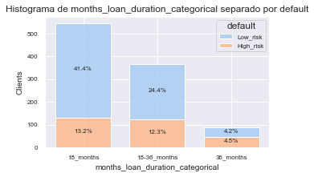

| default months_loan_duration_categorical | count High_risk | count Low_risk | percentage High_risk | percentage Low_risk | Overall_percentage |
| --- | --- | --- | --- | --- | --- |
| 18_months | 132 | 414 | 24.2% | 75.8% | 54.6% |
| 18-36_months | 123 | 244 | 33.5% | 66.5% | 36.7% |
| 36_months | 45 | 42 | 51.7% | 48.3% | 8.7% |

```python
plot_stacked_histplot(df, "months_loan_duration_categorical", "default")
show_summary_table(df, "months_loan_duration_categorical", "default")
```

Para la duración del prestamo que estan solicitando se observa que cuanto mayor es la duración de este mayor riesgo se asocia al cliente, lo cual tiene sentido y sigue nuestra intuición. Se observa que los prestamos de menos de 18 meses se asocian a un riesgo bajo para el 76% de los clientes y entre 18-36 meses al 67% ambos son muy cercanos a la media que se encuentra en el 70%. No obstante cuando se trata de prestamos de duración mayor a 36 meses se observa que tan solo el 48% se asocian a un riesgo bajo. Por tanto, podemos deducir que una duración del prestamos superior a los 3 años es una característica potencial de riesgo alto.

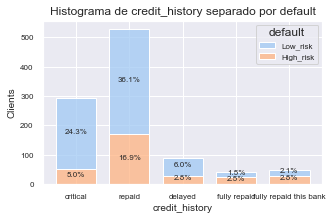

| default credit_history | count High_risk | count Low_risk | percentage High_risk | percentage Low_risk | Overall_percentage |
| --- | --- | --- | --- | --- | --- |
| repaid | 169 | 361 | 31.9% | 68.1% | 53.0% |
| critical | 50 | 243 | 17.1% | 82.9% | 29.3% |
| delayed | 28 | 60 | 31.8% | 68.2% | 8.8% |
| fully repaid this bank | 28 | 21 | 57.1% | 42.9% | 4.9% |
| fully repaid | 25 | 15 | 62.5% | 37.5% | 4.0% |

```python
plot_stacked_histplot(df, "credit_history", "default")
show_summary_table(df, "credit_history", "default")
```

Estos resultados son bastante confusos y nos hacen pensar que algo podría no estar bien en estos datos, ya que se observa que los clientes con un historial de crédito critico, es decir con inpagos tienen son asignados a una categoría de riesgo baja de forma más frecuente que la media, mientras que los clientes que han devuelto integramente los créditos que solicitaron se les asigna un riesgo alto con una frecuencia muy superior a la media, 63% y 57% respecto al 30% de promedio.

Si nos fijamos en el número de muestras se observa que *fully repaid* y *fully repaid this bank* tan solo contienen unas 40-50 muestras con lo que podrían estar sesgados estos datos por unas muestras poco extensas de estas categorías.

Cuando se finalice el EDA se analizará si esta variable se cogerá para el dataset definitivo o no.

Por otro lado se observa que *fully repaid* y *fully repaid this bank* son dos variables muy similares con unos resultados también similares, por lo que se va a optar por agruparlas, y así reducir ligeramente la complejidad de esta variable.

```python
# Group *fully repaid* y *fully repaid this bank* categories into *fully repaid*
df.loc[df.credit_history == "fully repaid this bank", "credit_history"] = "fully repaid"
```

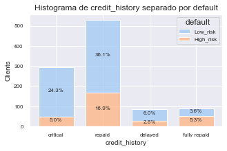

| default credit_history | count High_risk | count Low_risk | percentage High_risk | percentage Low_risk | Overall_percentage |
| --- | --- | --- | --- | --- | --- |
| repaid | 169 | 361 | 31.9% | 68.1% | 53.0% |
| critical | 50 | 243 | 17.1% | 82.9% | 29.3% |
| fully repaid | 53 | 36 | 59.6% | 40.4% | 8.9% |
| delayed | 28 | 60 | 31.8% | 68.2% | 8.8% |

```python
plot_stacked_histplot(df, "credit_history", "default")
show_summary_table(df, "credit_history", "default")
```

De esta forma quedan agrupadas las variables ahora.

A continuación se estudia la variable *purpose* donde se evalúa la intención del crédito.

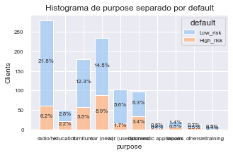

| default purpose | count High_risk | count Low_risk | percentage High_risk | percentage Low_risk | Overall_percentage |
| --- | --- | --- | --- | --- | --- |
| radio/tv | 62 | 218 | 22.1% | 77.9% | 28.0% |
| car (new) | 89 | 145 | 38.0% | 62.0% | 23.4% |
| furniture | 58 | 123 | 32.0% | 68.0% | 18.1% |
| car (used) | 17 | 86 | 16.5% | 83.5% | 10.3% |
| business | 34 | 63 | 35.1% | 64.9% | 9.7% |
| education | 22 | 28 | 44.0% | 56.0% | 5.0% |
| repairs | 8 | 14 | 36.4% | 63.6% | 2.2% |
| domestic appliances | 4 | 8 | 33.3% | 66.7% | 1.2% |
| others | 5 | 7 | 41.7% | 58.3% | 1.2% |
| retraining | 1 | 8 | 11.1% | 88.9% | 0.9% |

```python
plot_stacked_histplot(df, "purpose", "default")
show_summary_table(df, "purpose", "default")
```

En este atributo encontramos una gran cantidad de categoría, pero de ellas podemos sacar múltiples conclusiones. Primero de todo parece que cuando el crédito se sollicita para muebles, electrodomésticos o reparaciones del hogar los resultados se mantienen sobre la media. No obstante, cuando el prestamo se solicita para la compra de un vehículo usado o para la compra de una televisión o una radio el porcentaje que se asigna a un bajo riesgo es superior al promedio. Mientras que en el lado contrario, cuando el prestamo se solicita para un vehículo nuevo, reparaciones o para un negocio el porcentaje de riesgo alto es superior a la media.

Se observa que distintas categorias tienen una representación inferior al 5%, todas estas se van a agrupar bajo la variable "others"

```python
# Group the variables "repairs", "domestic appliances", "others" and "retraining" under the category "others"
for atribute in ["repairs", "domestic appliances", "retraining"]:
    df.loc[df.purpose == atribute, "purpose"] = "others"

df.purpose.unique()
```

```
array(['radio/tv', 'education', 'furniture', 'car (new)', 'car (used)',
       'business', 'others'], dtype=object)
```

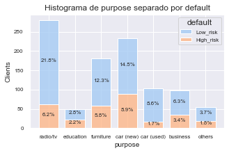

| default purpose | count High_risk | count Low_risk | percentage High_risk | percentage Low_risk | Overall_percentage |
| --- | --- | --- | --- | --- | --- |
| radio/tv | 62 | 218 | 22.1% | 77.9% | 28.0% |
| car (new) | 89 | 145 | 38.0% | 62.0% | 23.4% |
| furniture | 58 | 123 | 32.0% | 68.0% | 18.1% |
| car (used) | 17 | 86 | 16.5% | 83.5% | 10.3% |
| business | 34 | 63 | 35.1% | 64.9% | 9.7% |
| others | 18 | 37 | 32.7% | 67.3% | 5.5% |
| education | 22 | 28 | 44.0% | 56.0% | 5.0% |

```python
plot_stacked_histplot(df, "purpose", "default")
show_summary_table(df, "purpose", "default")
```

Con esta agrupación se reduce la complejidad de esta variable y ayudará a mejorar la calidad del modelo del árbol de decisión.

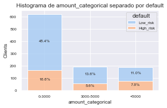

| default amount_categorical | count High_risk | count Low_risk | percentage High_risk | percentage Low_risk | Overall_percentage |
| --- | --- | --- | --- | --- | --- |
| 0-3000 | 166 | 454 | 26.8% | 73.2% | 62.0% |
| 3000-5000 | 56 | 136 | 29.2% | 70.8% | 19.2% |
| +5000 | 78 | 110 | 41.5% | 58.5% | 18.8% |

```python
plot_stacked_histplot(df, "amount_categorical", "default")
show_summary_table(df, "amount_categorical", "default")
```

Observamos que la mayor parte de los creditos que se solicitan son de un valor inferior a los 3000DM representando el 62% del total. Mientras que los prestamos de menor valor, es decir los de menos de 5000DM tienen un porcentaje de bajo riesgo cercano al del promedio, cuando se trata de prestamos de más de 5000DM el riesgo es superior, lo cual parece razonable. De esto obtenemos la cantidad del prestamo está directamente relacionada con el riesgo que supone ese prestamo.

A continuación se estudia la variable savings_balance que mide la cantidad de ahorros que tiene el solicitante del prestamo.

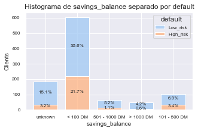

| default savings_balance | count High_risk | count Low_risk | percentage High_risk | percentage Low_risk | Overall_percentage |
| --- | --- | --- | --- | --- | --- |
| < 100 DM | 217 | 386 | 36.0% | 64.0% | 60.3% |
| unknown | 32 | 151 | 17.5% | 82.5% | 18.3% |
| 101 - 500 DM | 34 | 69 | 33.0% | 67.0% | 10.3% |
| 501 - 1000 DM | 11 | 52 | 17.5% | 82.5% | 6.3% |
| > 1000 DM | 6 | 42 | 12.5% | 87.5% | 4.8% |

```python
plot_stacked_histplot(df, "savings_balance", "default")
show_summary_table(df, "savings_balance", "default")
```

Se observa que el 60% de los solicitantes de un prestamo disponen de menos de 100DM de ahorros, mientras que tan solo el 11% tienen más de 500DM, lo cual es razonable, ya que será la gente que no tenga dinero que solicitará un prestamo. A la hora de asignar el nivel de riesgo se encuentra una correlación muy elevada, cuanto mayor es la cantidad de ahorros del solicitante mayor el porcentaje de clientes con un riesgo bajo. Esta variable parece ser muy buena a la hora de determinar el riesgo de un cliente.

A continuación se evalua la antigüedad laboral del cliente.

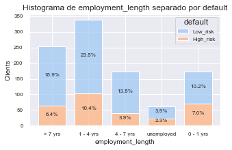

| default employment_length | count High_risk | count Low_risk | percentage High_risk | percentage Low_risk | Overall_percentage |
| --- | --- | --- | --- | --- | --- |
| 1 - 4 yrs | 104 | 235 | 30.7% | 69.3% | 33.9% |
| > 7 yrs | 64 | 189 | 25.3% | 74.7% | 25.3% |
| 4 - 7 yrs | 39 | 135 | 22.4% | 77.6% | 17.4% |
| 0 - 1 yrs | 70 | 102 | 40.7% | 59.3% | 17.2% |
| unemployed | 23 | 39 | 37.1% | 62.9% | 6.2% |

```python
plot_stacked_histplot(df, "employment_length", "default")
show_summary_table(df, "employment_length", "default")
```

Se observa que hay principalmente dos tipos de clientes, los que tienen una antigüedad de entre 1-4 años y los que tienen una antigüedad superior a los 7 años. Como se observaba en el gráfico de la edad de los clientes, la mayor parte de ellos se situaban entre 25 y 30 años, lo que hace que sea complicado que la antigüedad en su empleo sea muy elevada.

En cuanto a la influencia de esta variable sobre el riesgo se ve una influencia muy clara donde los clientes con menos de un año de experiencia o desempleados tienen un riesgo alto asignado en el 40,7% y 37,1% respectivamente, mientras que los clientes con una antigüedad de 4-7 años o > 7 años tienen un riesgo bajo en el 77,6% y 74,7% de los casos respectivamente. Esta variable parece ser muy relevante a la hora de asignar el nivel de riesgo de un cliente.

A continuación se trata la variable installment_rate, esta variable se comentó inicialmente que estaba discretizada y no se conocía exactamente a que corresponde cada valor, no obstante es interesante estudiarla para que en caso de que sea influyente se pueda tratar de obtener más información sobre ella.

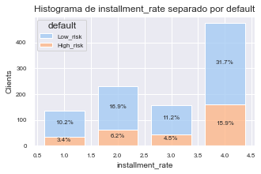

| default installment_rate | count High_risk | count Low_risk | percentage High_risk | percentage Low_risk | Overall_percentage |
| --- | --- | --- | --- | --- | --- |
| 4 | 159 | 317 | 33.4% | 66.6% | 47.6% |
| 2 | 62 | 169 | 26.8% | 73.2% | 23.1% |
| 3 | 45 | 112 | 28.7% | 71.3% | 15.7% |
| 1 | 34 | 102 | 25.0% | 75.0% | 13.6% |

```python
plot_stacked_histplot(df, "installment_rate", "default")
show_summary_table(df, "installment_rate", "default")
```

Se observa que la mayor parte de los clientes (47,6%) se han asignado a la categoría 4, la cual debe corresponder al mayor porcentaje de installment_rate ya que se le asinga el el menor porcentaje de riesgo bajo de todas las categorias. Además se observa como hay una relación directa entre el valor de installment rate y el nivel de riesgo asignado a los clientes habiendose asignado en mayor porcentaje un riesgo bajo a los clientes con un installment rate más bajo.

No obstante, también hay que destacar que aunque haya una relación aparente la diferencia en el porcentaje no es muy elevada.

A continuación se estudia la influencia de la situación sentimental.

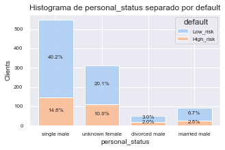

| default personal_status | count High_risk | count Low_risk | percentage High_risk | percentage Low_risk | Overall_percentage |
| --- | --- | --- | --- | --- | --- |
| single male | 146 | 402 | 26.6% | 73.4% | 54.8% |
| unknown female | 109 | 201 | 35.2% | 64.8% | 31.0% |
| married male | 25 | 67 | 27.2% | 72.8% | 9.2% |
| divorced male | 20 | 30 | 40.0% | 60.0% | 5.0% |

```python
plot_stacked_histplot(df, "personal_status", "default")
show_summary_table(df, "personal_status", "default")
```

Con este atributo como se ha mencionado previamente hay que vigilar con el sesgo correspondiente a que los clientes con estado sentimental corresponde a hombres mientras que los que son desconocidos son mujeres.

Independientemente de este hecho se observa que los hombre solteros y casados obtienen se les otorga un nivel de riesgo bajo con un porcentaje ligeramente superior al promedio, mientras que las mujeres y en especial los hombres divorciados obtienen un nivel de riesgo más alto que la media.

A continuación evaluamos la variable que hemos separado con exclusivamente el sexo del cliente.

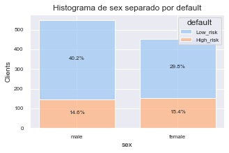

| default sex | count High_risk | count Low_risk | percentage High_risk | percentage Low_risk | Overall_percentage |
| --- | --- | --- | --- | --- | --- |
| male | 146 | 402 | 26.6% | 73.4% | 54.8% |
| female | 154 | 298 | 34.1% | 65.9% | 45.2% |

```python
plot_stacked_histplot(df, "sex", "default")
show_summary_table(df, "sex", "default")
```

Tanto esta variable como la anterior parecen tener una clara influencia en el nivel de riesgo que se asigna a un cliente, no obstante, dado que la discretización anterior dispone de más información y tan solo son 4 categorias se optará por esa en el estudio.

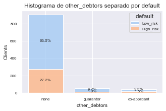

| default other_debtors | count High_risk | count Low_risk | percentage High_risk | percentage Low_risk | Overall_percentage |
| --- | --- | --- | --- | --- | --- |
| none | 272 | 635 | 30.0% | 70.0% | 90.7% |
| guarantor | 10 | 42 | 19.2% | 80.8% | 5.2% |
| co-applicant | 18 | 23 | 43.9% | 56.1% | 4.1% |

```python
plot_stacked_histplot(df, "other_debtors", "default")
show_summary_table(df, "other_debtors", "default")
```

Se observa que en un porcentaje muy elevado (90,7%) el solicitante del credito lo hace el solo, no obstante es interesante observar como los clientes que solicitan el prestamo con un abal se les asigna un nivel de riesgo bajo en un porcentaje muy superior a la media, 80,8%, mientras que los que lo hacen con un co-titular sorprendetemente obtienen un nivel de riesgo más elevado.

Esta variable parece mostrar relación clara con el nivel de riesgo, no obstante, que el 91% de las muestras se encuentren en una misma categoría supone una gran influencia.

A continuación se evalua la variable residence history que muestra el número de viviendas previas que ha tenido el solicitante del credito.

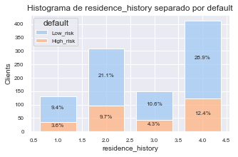

| default residence_history | count High_risk | count Low_risk | percentage High_risk | percentage Low_risk | Overall_percentage |
| --- | --- | --- | --- | --- | --- |
| 4 | 124 | 289 | 30.0% | 70.0% | 41.3% |
| 2 | 97 | 211 | 31.5% | 68.5% | 30.8% |
| 3 | 43 | 106 | 28.9% | 71.1% | 14.9% |
| 1 | 36 | 94 | 27.7% | 72.3% | 13.0% |

```python
plot_stacked_histplot(df, "residence_history", "default")
show_summary_table(df, "residence_history", "default")
```

Se observa que la mayor parte de los clientes han vivido en 2 o 4 viviendas distintas (30,8% y 41,3% respectivamente). En cuanto a la influencia que esta variable muestra sobre el nivel de riesgo se aprecia bastante reducida ya que para cualquier número de viviendas el resultado es muy similar.

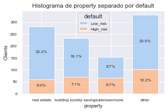

| default property | count High_risk | count Low_risk | percentage High_risk | percentage Low_risk | Overall_percentage |
| --- | --- | --- | --- | --- | --- |
| other | 102 | 230 | 30.7% | 69.3% | 33.2% |
| real estate | 60 | 222 | 21.3% | 78.7% | 28.2% |
| building society savings | 71 | 161 | 30.6% | 69.4% | 23.2% |
| unknown/none | 67 | 87 | 43.5% | 56.5% | 15.4% |

```python
plot_stacked_histplot(df, "property", "default")
show_summary_table(df, "property", "default")
```

Para esta variable la mayoría de los clientes la vivienda que poseen está muy distribuido entre other, inmobiliario y de protección social. Se observa que para los clientes que tienen una vivienda inmobiliaria su nivel de riesgo es más bajo que la media, mientras que los clientes sin vivienda o que no se sabe si la poseen su riesgo es mucho más elevado que el promedio. Para los clientes que su vivienda es de protección social o de otro tipo su nivel de riesgo es según la media.

A continuación se evalúa la influencia de la edad.

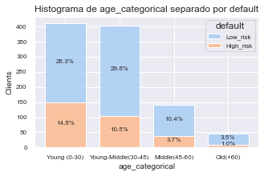

| default age_categorical | count High_risk | count Low_risk | percentage High_risk | percentage Low_risk | Overall_percentage |
| --- | --- | --- | --- | --- | --- |
| Young (0-30) | 148 | 263 | 36.0% | 64.0% | 41.1% |
| Young-Middle(30-45) | 105 | 298 | 26.1% | 73.9% | 40.3% |
| Middle(45-60) | 37 | 104 | 26.2% | 73.8% | 14.1% |
| Old(+60) | 10 | 35 | 22.2% | 77.8% | 4.5% |

```python
plot_stacked_histplot(df, "age_categorical", "default")
show_summary_table(df, "age_categorical", "default")
```

Se observa que la mayor parte de los clientes se encuentran o en el rango 0-30 o en 30-45 suponiendo el 41,1% y el 40,3% del total. También se observa una clara relación entre el nivel de riesgo siendo más bajo en clientes de mayor edad y más alto en clientes de menor edad.

Esta variable será de gran utilidad dada su relación directa con la variable objetivo.

A continuación se evalua la variable installment plan que evalua la presencia de otros prestamos con el bank o en tiendas.

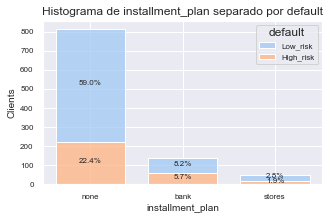

| default installment_plan | count High_risk | count Low_risk | percentage High_risk | percentage Low_risk | Overall_percentage |
| --- | --- | --- | --- | --- | --- |
| none | 224 | 590 | 27.5% | 72.5% | 81.4% |
| bank | 57 | 82 | 41.0% | 59.0% | 13.9% |
| stores | 19 | 28 | 40.4% | 59.6% | 4.7% |

```python
plot_stacked_histplot(df, "installment_plan", "default")
show_summary_table(df, "installment_plan", "default")
```

Se observa que la mayor parte de los clientes no tienen otros prestamos representando esta categoria el 81,4%, no obstante los clientes que si que disponen de otros prestamos obtinen un porcentaje de riesgo muy superior al promedio.

Dado que tanto si es un prestamo con el banco como en una tienda los porcentajes para el nivel de riesgo son similares se agruparan estas dos categorias bajo una única "yes".

```python
df.loc[df.installment_plan == "bank", "installment_plan"] = "yes"
df.loc[df.installment_plan == "stores", "installment_plan"] = "yes"
```

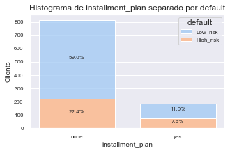

| default installment_plan | count High_risk | count Low_risk | percentage High_risk | percentage Low_risk | Overall_percentage |
| --- | --- | --- | --- | --- | --- |
| none | 224 | 590 | 27.5% | 72.5% | 81.4% |
| yes | 76 | 110 | 40.9% | 59.1% | 18.6% |

```python
plot_stacked_histplot(df, "installment_plan", "default")
show_summary_table(df, "installment_plan", "default")
```

Ahora quedan agrupadas las categorías obteniendo unos resultados muy similares y simplificando la discretización.

A continuación se evalúa la variable housing que discretiza los clientes en función de si viven en su propia vivienda y si pagan alquiler o han adquirido la vivienda.

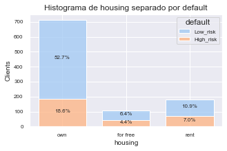

| default housing | count High_risk | count Low_risk | percentage High_risk | percentage Low_risk | Overall_percentage |
| --- | --- | --- | --- | --- | --- |
| own | 186 | 527 | 26.1% | 73.9% | 71.3% |
| rent | 70 | 109 | 39.1% | 60.9% | 17.9% |
| for free | 44 | 64 | 40.7% | 59.3% | 10.8% |

```python
plot_stacked_histplot(df, "housing", "default")
show_summary_table(df, "housing", "default")
```

Se observa que el 71,3% de los clientes que solicitan el prestamo tienen su propia vivienda y su nivel de riesgo es ligeramente inferior a la media. No obstante, lo interesante de esta variable aparece que en que los clientes que viven de alquiler o no tienen vivienda su nivel de riesgo es significativamente superior a la media.

A continuación se estudia la influencia de la existencia de otros creditos.

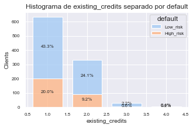

| default existing_credits | count High_risk | count Low_risk | percentage High_risk | percentage Low_risk | Overall_percentage |
| --- | --- | --- | --- | --- | --- |
| 1 | 200 | 433 | 31.6% | 68.4% | 63.3% |
| 2 | 92 | 241 | 27.6% | 72.4% | 33.3% |
| 3 | 6 | 22 | 21.4% | 78.6% | 2.8% |
| 4 | 2 | 4 | 33.3% | 66.7% | 0.6% |

```python
plot_stacked_histplot(df, "existing_credits", "default")
show_summary_table(df, "existing_credits", "default")
```

Se observa que la mayor parte de los clientes ya poseen uno o dos creditos (63,3% y 33,3% respectivamente). No obstante, esta variable parece no tener una gran influencia, ya que el único grupo que se aleja de la media es el de 3 préstamos, el cual corresponde a tan solo en 2,8% del dataset.

A continuación se evalúa la influencia de la cantidad de dependientes del solicitante.

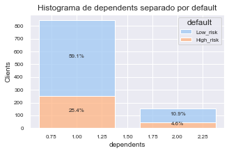

| default dependents | count High_risk | count Low_risk | percentage High_risk | percentage Low_risk | Overall_percentage |
| --- | --- | --- | --- | --- | --- |
| 1 | 254 | 591 | 30.1% | 69.9% | 84.5% |
| 2 | 46 | 109 | 29.7% | 70.3% | 15.5% |

```python
plot_stacked_histplot(df, "dependents", "default")
show_summary_table(df, "dependents", "default")
```

La mayor parte de los solicitantes tienen un dependiente, no obstante su nivel de riesgo es muy similar al promedio al igual que aquellos que tienen 2 dependientes. Por tanto, esta variable parece tener una influencia muy baja en el nivel de riesgo.

A continuación se evalua la influencia de tener teléfono sobre el riesgo de un cliente a la hora de asignarle un crédito.

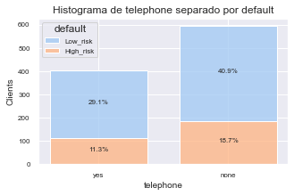

| default telephone | count High_risk | count Low_risk | percentage High_risk | percentage Low_risk | Overall_percentage |
| --- | --- | --- | --- | --- | --- |
| none | 187 | 409 | 31.4% | 68.6% | 59.6% |
| yes | 113 | 291 | 28.0% | 72.0% | 40.4% |

```python
plot_stacked_histplot(df, "telephone", "default")
show_summary_table(df, "telephone", "default")
```

El atributo del teléfono intuitivamente no parece estar relacionada con el riesgo de devolver el crédito y así lo verifican los resultados obtenidos donde tanto los clientes sin teléfono como lo que si que lo tienen obtienen una probabilidad de asignarlos a bajo riesgo cercana al 70%, con lo que esta variable parece que no será de gran interés a la hora de determiar el riesgo de un cliente.

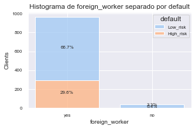

| default foreign_worker | count High_risk | count Low_risk | percentage High_risk | percentage Low_risk | Overall_percentage |
| --- | --- | --- | --- | --- | --- |
| yes | 296 | 667 | 30.7% | 69.3% | 96.3% |
| no | 4 | 33 | 10.8% | 89.2% | 3.7% |

```python
plot_stacked_histplot(df, "foreign_worker", "default")
show_summary_table(df, "foreign_worker", "default")
```

Se observa que el 96,3% de los clientes son trabajadores extranjeros, por lo cual esta variable esta muy sesgada. A pesar de que aquellos que no son trabajadores extranjeros en el 89% de los casos se les asigna un nivel de riesgo bajo, no se puede puede tener esto en cuenta dado que son menos de un 4% del total.

Finalmente, analizaremos la influencia del trabajo.

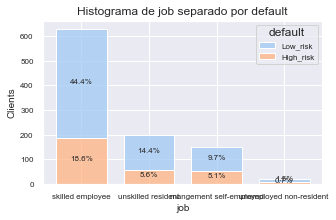

| default job | count High_risk | count Low_risk | percentage High_risk | percentage Low_risk | Overall_percentage |
| --- | --- | --- | --- | --- | --- |
| skilled employee | 186 | 444 | 29.5% | 70.5% | 63.0% |
| unskilled resident | 56 | 144 | 28.0% | 72.0% | 20.0% |
| mangement self-employed | 51 | 97 | 34.5% | 65.5% | 14.8% |
| unemployed non-resident | 7 | 15 | 31.8% | 68.2% | 2.2% |

```python
plot_stacked_histplot(df, "job", "default")
show_summary_table(df, "job", "default")
```

Se observa que la mayor parte de los solicitantes de un credito son trabajadores cualificados, a los cuales se les asigna un riesgo bajo en el 70,5% de las ocasiones, un valor muy cercano al promedio. En cuanto a los residentes no cualificados también se les asigna un riesgo bajo en el 72% de las ocasiones, el cual es ligeramente superior a la media. Es al los trabajadores por cuenta propia a los que se les asigna un riesgo alto en mayor proporción que a la media, pero tampoco de una forma muy acentuada.

Podríamos concluir que el tipo de trabajo de un cliente no tendrá una gran influencia en la determinación del riesgo a devolver el credito.

### 1.2.2. Conclusiones

Del análisis de las variables categóricas se extraen como conclusión que algunas variables tienen una influencia muy elevada con el nivel de riesgo mientras que otras muestran una relación escasa o meramente casual. También se ha osbervado que ciertas variables estaban muy sesgadas correspondiendo la mayor parte de sus muestras a una o dos categorías lo cual reduce la utilidad de esos atributos.

Las variables *months_loan_duration*, *amount*, *savings_balance*, *employment_length*, *age*, *installment_plan* y *housing* han demostrado tener una relación muy elevada con el nivel de riesgo asignado a un cliente. Otras como *purpose*, *installment_rate*, *personal_status* y *property* también han mostrado resultados muy buenos pero con algunos matices, ya que la mayoría de ellas eran muy claras con algunas categorías pero con otras no aportaban mucha información.

Por el lado contrario nos encontramos con algunos atributos que no son muy apropiados para este estudio este caso son por un lado: *checking_balance* la cual a pesar de ser muy buena contiene casi un 40% de valores nulos. *credit_history* al igual que *existing_credits* aporta unos resultados que al contrastarlos con nuestro conocimiento son extraños. *sex* se decarta porque personal_status aporta una información más completa y ya incorpora la separación por sexos. *other_debtors* y *foreign_worker* poseen una categoria que engloba más del 90% de los resultados. Finalmente, *residence_history*, *dependants*, *telephone* y *job* parecen no tener ninguna influencia sobre el nivel de riesgo.

Tras evaluar *checking_balance* y *savings_balance* se intuye que puede haber una correlación entre las dos, por ello se decide transformar estas variables a numérico tomando el valor promedio de sus rangos y poder estudiar su posible correlación.

A continuación se estudiarán las variables numericas y con todo ello se determinará el dataset final.

## 1.3. Variables numéricas

### 1.3.1. Análisis de las variables numéricas

En este apartado se van a estudiar las distintas variables numéricas con el objetivo de tratar de encontrar cuales de ellas pueden estar correlacionadas y la influencia que tienen con la variable objetivo.

```python
# Generate the numerical column for checking_balance
df["checking_balance_num"] = ""
df.loc[df.checking_balance == "< 0 DM", "checking_balance_num"] = 0
df.loc[df.checking_balance == "1 - 200 DM", "checking_balance_num"] = 100
df.loc[df.checking_balance == "> 200 DM", "checking_balance_num"] = 400
df.loc[df.checking_balance == "unknown", "checking_balance_num"] = -100

# Generate the numerical column for savings_balance
df["savings_balance_num"] = ""
df.loc[df.savings_balance == "unknown", "savings_balance_num"] = -100
df.loc[df.savings_balance == "< 100 DM", "savings_balance_num"] = 50
df.loc[df.savings_balance == "101 - 500 DM", "savings_balance_num"] = 250
df.loc[df.savings_balance == "501 - 1000 DM", "savings_balance_num"] = 750
df.loc[df.savings_balance == "> 1000 DM", "savings_balance_num"] = 2000

# Assign an integer type to the two new variables
df["checking_balance_num"] = df["checking_balance_num"].astype(int)
df["savings_balance_num"] = df["savings_balance_num"].astype(int)

# Show the first rows of the dataframe to check the results
df.head()
```

|  | checking_balance | months_loan_duration | credit_history | purpose | amount | savings_balance | employment_length | installment_rate | personal_status | other_debtors | ... | dependents | telephone | foreign_worker | job | months_loan_duration_categorical | age_categorical | amount_categorical | sex | checking_balance_num | savings_balance_num |
| --- | --- | --- | --- | --- | --- | --- | --- | --- | --- | --- | --- | --- | --- | --- | --- | --- | --- | --- | --- | --- | --- |
| 0 | < 0 DM | 6 | critical | radio/tv | 1169 | unknown | > 7 yrs | 4 | single male | none | ... | 1 | yes | yes | skilled employee | 18_months | Old(+60) | 0-3000 | male | 0 | -100 |
| 1 | 1 - 200 DM | 48 | repaid | radio/tv | 5951 | < 100 DM | 1 - 4 yrs | 2 | unknown female | none | ... | 1 | none | yes | skilled employee | 36_months | Young (0-30) | +5000 | female | 100 | 50 |
| 2 | unknown | 12 | critical | education | 2096 | < 100 DM | 4 - 7 yrs | 2 | single male | none | ... | 2 | none | yes | unskilled resident | 18_months | Middle(45-60) | 0-3000 | male | -100 | 50 |
| 3 | < 0 DM | 42 | repaid | furniture | 7882 | < 100 DM | 4 - 7 yrs | 2 | single male | guarantor | ... | 2 | none | yes | skilled employee | 36_months | Young-Middle(30-45) | +5000 | male | 0 | 50 |
| 4 | < 0 DM | 24 | delayed | car (new) | 4870 | < 100 DM | 1 - 4 yrs | 3 | single male | none | ... | 2 | none | yes | skilled employee | 18-36_months | Middle(45-60) | 3000-5000 | male | 0 | 50 |

5 rows × 27 columns

Ahora podemos evaluar las distintas variables numéricas que son: *months_loan_duration*, *amount*, *residence_history*, *age*, *existing_credits* y *dependents* además hemos añadido *checking_balance* y *savings_balance*.

A continuación se muestra un pairplot con hue aplicado a la variable default, para poder evaluar la correlación entre las distintas variables numericas y la distribución de los clientes con riesgo bajo y con riesgo alto.

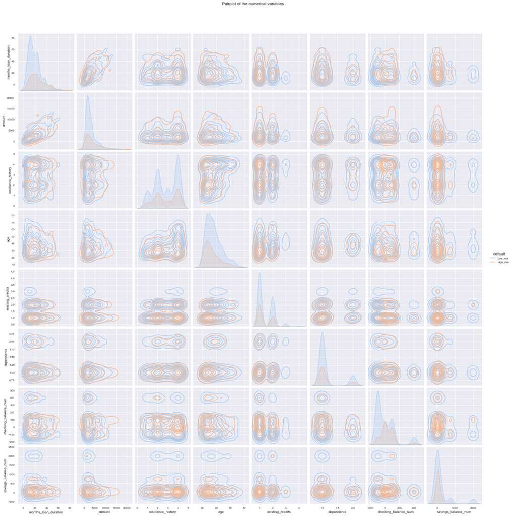

```python
# Generate a datframe with the numerical variables
df_num = pd.DataFrame(df, columns = ["months_loan_duration", "amount", "residence_history", "age", "existing_credits", "dependents", "checking_balance_num", "savings_balance_num", "default"])

# Asign the figure size
plt.figure(figsize=(8,8))

# Generate a pairplot of density to avoid overplotting
ax = sns.pairplot(data = df_num, kind="kde", hue="default")

# Set title and others
plt.suptitle("Pairplot of the numerical variables", y = 1.05)

# Plot the pairplot
plt.show()
```

Se observa que la mayoría de variables no muestran una correlación entre ellas a excepción de *amount* y *months_loan_duration* el cual parece razonable ya que si el prestamo es más elevado, es lógico que se necesiten más meses para pagarlo.

En cuanto a la variable *default* se observa que sigue una distribución bastante similar para la categoría riesgo alto y riesgo bajo. Podemos observar como en los meses de duración las duraciones más reducidas son las que concentran la mayor parte de las asignaciones de riego bajo, al igual que sucede con la cantidad, que las más bajas son las que tienen el mayot pico. Por otro lado se observa que curva de densidad para la edad esta más desplazada hacia edades bajas en riesgo alto mientras que la de riesgo bajo está más distribuida.

A continuación se estudia detalladamente la relación entre *checking_balance* y *savings_balance* mediante un scatterplot.

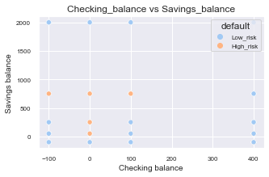

```python
# Assign figure dimensions
plt.figure(figsize=(5,3))

# Create the scatterplot
ax = sns.scatterplot(data = df, x = "checking_balance_num", y = "savings_balance_num", hue = "default")

# Set title and others
plt.title("Checking_balance vs Savings_balance")
plt.xlabel("Checking balance")
plt.ylabel("Savings balance")


# Plot the scatterplot
plt.show()
```

Del scatterplot se observa que al tratarse de variables discretas se produce overplotting y no se pueden obtener conclusiones claras de este gráfico, por ello se opta por un gráfico de densidad.

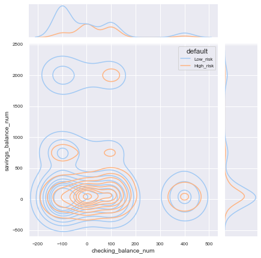

```python
sns.jointplot(x = df.checking_balance_num, y = df.savings_balance_num, kind = "kde", hue = df.default)
```

Tras estudiar esta variable más en profundidad se observa que *checking_balance* tienen una mayor distribución que *savings_balance* y que su correlación no es tan elevada como se esperaba incialmente.

### 1.3.2. Conclusiones

Tras estudiar las variables numéricas se deduce que dos de ellas tienen una correlación alta que son *amount* y *months_loan_duration* las cuales para una mayor cantidad de prestamo equivale a una mayor duración de este. No obstante, el resto de las variables no parecen estar muy correlacionadas entre ellas.

En cuanto a su relación con la variable objetivo, se observa que para la mayoría de las variables la distribución de los clientes con un nivel de riesgo bajo es muy similar a la de los clientes con un riesgo alto, con la excepción de *age*, la cual también se había observado en su variante categórica, que para clientes de menor edad el riesgo es más elevado y para la variable *amount* y *month_loan_duration* se observa que para duraciones y cantidades más bajas el nivel de riesgo es inferior que para las más altas.

# 2. Primer árbol de decisión

## 2.1. Preparación de los datos

Se ha observado que un seguido de atributos no aportaban información, estaban sesgados o su información no era clara, para mejorar la calidad del modelo obtenido se ha optado por descartar estos atributos que son: *credit_history*, *sex*, *other_debtors*, *residence_history*, *existing_credits*, *dependants*, *telephone*, *foreign_worker* y *job*. A continuación se genera el dataset de estudio.

```python
# Generation of the dataset
df_def = df[["default", "checking_balance", "months_loan_duration", "purpose", "amount", "savings_balance",
"employment_length", "installment_rate", "personal_status", "property", "age", "installment_plan", "housing"]]

# Showing the dataset to check if everything is right
df_def.head()
```

|  | default | checking_balance | months_loan_duration | purpose | amount | savings_balance | employment_length | installment_rate | personal_status | property | age | installment_plan | housing |
| --- | --- | --- | --- | --- | --- | --- | --- | --- | --- | --- | --- | --- | --- |
| 0 | Low_risk | < 0 DM | 6 | radio/tv | 1169 | unknown | > 7 yrs | 4 | single male | real estate | 67 | none | own |
| 1 | High_risk | 1 - 200 DM | 48 | radio/tv | 5951 | < 100 DM | 1 - 4 yrs | 2 | unknown female | real estate | 22 | none | own |
| 2 | Low_risk | unknown | 12 | education | 2096 | < 100 DM | 4 - 7 yrs | 2 | single male | real estate | 49 | none | own |
| 3 | Low_risk | < 0 DM | 42 | furniture | 7882 | < 100 DM | 4 - 7 yrs | 2 | single male | building society savings | 45 | none | for free |
| 4 | High_risk | < 0 DM | 24 | car (new) | 4870 | < 100 DM | 1 - 4 yrs | 3 | single male | unknown/none | 53 | none | for free |

A la hora de aplicar un árbol de decisión en Python con la librería scikit learn, se empleará una versión optimizada del algoritmo CART el cual no acepta variables categoricas, por ello la opción por la que debemos optar consiste en aplicar un One Hot Encoder que nos transforme las variables categóricas en n variables binarias (donde n es el número de categorias de la variable). De esta forma todas las variables pasarán a ser de tipo numérico. Se opta por emplear el método get_dummies de la librería pandas [1].

- default: 0 - Low Risk; 1 - High Risk
- installment_plan: 0 - none; 1 - yes

```python
# Apply one hot encoder to the dataframe
df_def_enc = pd.get_dummies(data = df_def, columns = ["checking_balance", "purpose", "savings_balance", "property", "employment_length", "personal_status", "housing"])

# Substitute with numerical values of default
df_def_enc.loc[df_def_enc.default == "Low_risk", "default"] = 0
df_def_enc.loc[df_def_enc.default == "High_risk", "default"] = 1
df_def_enc["default"] = df_def_enc.default.astype(int)

# Substitute with numerical values of installment_plan
df_def_enc.loc[df_def_enc.installment_plan == "none", "installment_plan"] = 0
df_def_enc.loc[df_def_enc.installment_plan == "yes", "installment_plan"] = 1
df_def_enc["installment_plan"] = df_def_enc.installment_plan.astype(int)

# Show the dataframe
df_def_enc.head()
df_def_enc.dtypes
```

```
default                              int64
months_loan_duration                 int64
amount                               int64
installment_rate                     int64
age                                  int64
installment_plan                     int64
checking_balance_1 - 200 DM          uint8
checking_balance_< 0 DM              uint8
checking_balance_> 200 DM            uint8
checking_balance_unknown             uint8
purpose_business                     uint8
purpose_car (new)                    uint8
purpose_car (used)                   uint8
purpose_education                    uint8
purpose_furniture                    uint8
purpose_others                       uint8
purpose_radio/tv                     uint8
savings_balance_101 - 500 DM         uint8
savings_balance_501 - 1000 DM        uint8
savings_balance_< 100 DM             uint8
savings_balance_> 1000 DM            uint8
savings_balance_unknown              uint8
property_building society savings    uint8
property_other                       uint8
property_real estate                 uint8
property_unknown/none                uint8
employment_length_0 - 1 yrs          uint8
employment_length_1 - 4 yrs          uint8
employment_length_4 - 7 yrs          uint8
employment_length_> 7 yrs            uint8
employment_length_unemployed         uint8
personal_status_divorced male        uint8
personal_status_married male         uint8
personal_status_single male          uint8
personal_status_unknown female       uint8
housing_for free                     uint8
housing_own                          uint8
housing_rent                         uint8
dtype: object
```

Una vez generado el dataset se procede a generar el grupo de los datos de entreno y un conjunto de prueba, para poder entrenar el modelo con los datos de entreno y posteriormente cuantificar la calidad de este con los de prueba. Se podría añadir un tercer dataset de verificación, pero dado que la cantidad de datos de la que disponemos no es muy elevada nos quedaremos con estos dos.

Se ha optado por separar los datos con una proporcion a tercios, es decir 2/3 serán el conjunto de datos de entreno y 1/3 los de prueba.

Para una mayor reproducibilidad del código se opta por fijar la semilla, para que así la distribución aleatoria de los datos siempre sea la misma. Es decir, aunque inicialmente obtendremos un grupo aleatorio de datos, siempre que ejecutemos el código obtendremos el mismo grupo aleatorio. Esto se hace mediante la fijación de un random_state al aplicar train_test_split().

```python
# Save the features dataframe and the goal serie
y = df_def_enc.default
X = df_def_enc.drop("default", axis = 1)

# Assign the different group of training and test data
X_train, X_test, y_train, y_test = train_test_split(X, y, test_size=0.33, random_state = 23)
```

A continuación verificamos que el grupo que hemos obtenido realmente sea representativo del conjunto global del dataset. Con Python este proceso es un poco más complejo al no disponer de una función que nos genere un resumen de las distintas variables categoricas. Para ello verificaremos con la variable objetivo que realmente obtengamos una proporción cercana al 70% de clientes asignados con un nivel de riesgo bajo.

```python
y_train.value_counts()
```

```
0    468
1    202
Name: default, dtype: int64
```

Obtenemos una proporción del 69,85% asignado a bajo riesgo, una proporción muy similar a la del dataset completo. Se podrían estudiar las distintas variables y verificar que efectivamente todas ellas siguen una proporción similar, se opta por confiar en los resultados obtenidos en la columna objetivo y continuar con el modelo.

## 2.2. Generación del primer árbol de decisión

Para la generación del árbol de decisión se escogerá el modelo árbol de decisión incluido en el paquete de scikit learn DecisionTreeClassifier el cual se basa en una optimización del algoritmo CART, el cual es muy similar al algoritmo C4.5, con la diferencia de que también funciona como modelo de regresión y no computa los sets de reglas. Para la implementación de este modelo se ha tomado como referencia el código de [2].

```python
def dec_tree(depth):
    # Generate the model and fit it with the training data
    clf = tree.DecisionTreeClassifier(max_depth = depth, random_state = 2)
    clf = clf.fit(X_train, y_train)

    # Evaluate the precission of the model
    y_pred = clf.predict(X_test)
    return (metrics.accuracy_score(y_test, y_pred), clf)

(acc, clf) = dec_tree(4)
print("La precisión del arbol de decisión con una profundidad de 4 es del {:.1%}".format(acc))
```

```
La precisión del arbol de decisión con una profundidad de 4 es del 70.9%
```

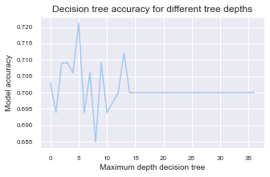

```python
# List containing the accuracy of the different models
model_accuracy = []

# Loop that generates a model and evaluates it for different depths
for i in range(37):
    acc = dec_tree(i+1)
    model_accuracy.append(acc[0])

# Show the accuracy in a plot
# Assign figure dimensions
plt.figure(figsize=(5,3))

# Create the scatterplot
ax = plt.plot(model_accuracy)

# Set title and others
plt.title("Decision tree accuracy for different tree depths")
plt.xlabel("Maximum depth decision tree")
plt.ylabel("Model accuracy")

# Plot the scatterplot
plt.show()
```